```python
import tensorflow as tf
from tensorflow import keras
```

```python
import pandas as pd
import matplotlib.pyplot as plt
import seaborn as sns
```

# Natural Language Processing with Disaster Tweets

```python
train = pd.read_csv("train.csv")
test = pd.read_csv("test.csv")
```

## Description of Problem and Data

The overall goal of this kaggle competition is to be able to predict whether a tweet in this dataset is about a real disaster or not. 1=yes, real disaster. 0=no, not about a real disaster. The test data contains 4 columns/variable that are id, text, location, and keyword. The train set has these same 4 columns but an additional one of target. The id depicts the ID number for the tweet, the text is the actual text the tweet contains, location is the location where the tweet was sent, keyword is a keyword from the tweet, and target is a 1 or a 0 denoting if a tweet is real or not.

```python
# description of the data
print(len(train))
print(len(test))
```

```
7613
3263
```

This shows that the data is split with about 70% train and 30% test data and totals about 10,000+ entires

```python
train.head()
```

|  | id | keyword | location | text | target |
| --- | --- | --- | --- | --- | --- |
| 0 | 1 | NaN | NaN | Our Deeds are the Reason of this #earthquake M... | 1 |
| 1 | 4 | NaN | NaN | Forest fire near La Ronge Sask. Canada | 1 |
| 2 | 5 | NaN | NaN | All residents asked to 'shelter in place' are ... | 1 |
| 3 | 6 | NaN | NaN | 13,000 people receive #wildfires evacuation or... | 1 |
| 4 | 7 | NaN | NaN | Just got sent this photo from Ruby #Alaska as ... | 1 |

```python
test.head()
```

|  | id | keyword | location | text |
| --- | --- | --- | --- | --- |
| 0 | 0 | NaN | NaN | Just happened a terrible car crash |
| 1 | 2 | NaN | NaN | Heard about #earthquake is different cities, s... |
| 2 | 3 | NaN | NaN | there is a forest fire at spot pond, geese are... |
| 3 | 9 | NaN | NaN | Apocalypse lighting. #Spokane #wildfires |
| 4 | 11 | NaN | NaN | Typhoon Soudelor kills 28 in China and Taiwan |

```python
# looking at null values
train.isna().sum()
```

```
id             0
keyword       61
location    2533
text           0
target         0
dtype: int64
```

```python
test.isna().sum()
```

```
id             0
keyword       26
location    1105
text           0
dtype: int64
```

There are a lot of null values in both the test and train data set for the location and keyword column.

```python
# seeing how many 1 and 0's are in the train set
train.target.value_counts()
```

```
0    4342
1    3271
Name: target, dtype: int64
```

"real disaster" vs "not real disaster" are almost evenly distributed but with more classified as "not a real disaster"

```python
train.describe()
```

|  | id | target |
| --- | --- | --- |
| count | 7613.000000 | 7613.00000 |
| mean | 5441.934848 | 0.42966 |
| std | 3137.116090 | 0.49506 |
| min | 1.000000 | 0.00000 |
| 25% | 2734.000000 | 0.00000 |
| 50% | 5408.000000 | 0.00000 |
| 75% | 8146.000000 | 1.00000 |
| max | 10873.000000 | 1.00000 |

```python
test.describe()
```

|  | id |
| --- | --- |
| count | 3263.000000 |
| mean | 5427.152927 |
| std | 3146.427221 |
| min | 0.000000 |
| 25% | 2683.000000 |
| 50% | 5500.000000 |
| 75% | 8176.000000 |
| max | 10875.000000 |

## Exploratory Data Analysis and Cleaning

### EDA and Visualizations

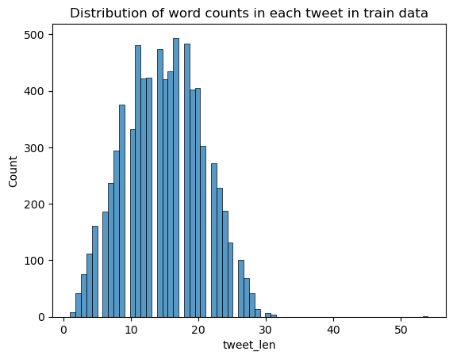

```python
# looking at the length of the tweets in the training set
train['tweet_len'] = train['text'].apply(lambda x: len(x.split(' ')))

sns.histplot(train['tweet_len'])

plt.title("Distribution of word counts in each tweet in train data")
```

This shows that most of the tweets in the train data set range from 0 to 30 words with the majority being around 10-20 words, overall short in length.

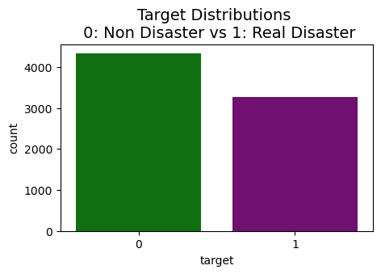

```python
#looking at the comparison between 1 and 0 for the target variable
plt.figure(figsize=(5,3))
colors = ["green", "purple"]

sns.countplot(x = 'target', data=train, palette=colors)
plt.title('Target Distributions \n 0: Non Disaster vs 1: Real Disaster', fontsize=14)
```

## Data Cleaning

Since I am only going to be using the id, text, and target columns for data analysis and prediction.

```python
# dropping columns not being used for train dataaset
train1 = train.drop(['location', 'keyword', 'tweet_len'], axis=1)
train1.head()
```

|  | id | text | target |
| --- | --- | --- | --- |
| 0 | 1 | Our Deeds are the Reason of this #earthquake M... | 1 |
| 1 | 4 | Forest fire near La Ronge Sask. Canada | 1 |
| 2 | 5 | All residents asked to 'shelter in place' are ... | 1 |
| 3 | 6 | 13,000 people receive #wildfires evacuation or... | 1 |
| 4 | 7 | Just got sent this photo from Ruby #Alaska as ... | 1 |

```python
# dropping columns not being used for test dataset
test1 = test.drop(['location', 'keyword'], axis=1)
test1.head()
```

|  | id | text |
| --- | --- | --- |
| 0 | 0 | Just happened a terrible car crash |
| 1 | 2 | Heard about #earthquake is different cities, s... |
| 2 | 3 | there is a forest fire at spot pond, geese are... |
| 3 | 9 | Apocalypse lighting. #Spokane #wildfires |
| 4 | 11 | Typhoon Soudelor kills 28 in China and Taiwan |

## Model Architecture

The word embeding process I am going to use is TF-IDF. TF-IDF stands for Term Frequency-Inverse Document Frequency and it is an algorithm used to determine how relevant words in a document are by using the frequency of the word. I thought this method of word embeding would be the best over other methods because it takes less steps to get the relevancy of the terms from this data set into a vector form, other methods would take extra steps and time to do that.

### TF-IDF

```python
from sklearn.feature_extraction.text import TfidfVectorizer
# creating a vectorizer using TF-IDF
vectorizer = TfidfVectorizer(max_features=5000)

# Transform text data
X = vectorizer.fit_transform(train1["text"])
y = train1["target"]
```

```python
from sklearn.model_selection import train_test_split
# training the data first
X_train, X_test, y_train, y_test = train_test_split(X, y, test_size=0.2, random_state=42)
```

```python
# checking shape of data to see if I split it correctly
print(X_train.shape)
print(X_test.shape)
print(y_train.shape)
print(y_test.shape)
```

```
(6090, 5000)
(1523, 5000)
(6090,)
(1523,)
```

## LSTM Model

```python
import numpy as np
from tensorflow.keras.models import Sequential
from tensorflow.keras.layers import Embedding, LSTM, Dense
```

```python
# Convert TF-IDF matrix to a dense NumPy array
X = X.toarray()
```

```python
# Split the data into training and testing sets
X_train, X_test, y_train, y_test = train_test_split(X, train1["target"], test_size=0.2, random_state=42)
```

```python
# Define the LSTM model
model = Sequential()
model.add(Embedding(input_dim=5000, output_dim=128, input_length=X_train.shape[1]))
model.add(LSTM(100))
model.add(Dense(1, activation='sigmoid'))
```

```python
# Compile the model
model.compile(loss='binary_crossentropy', optimizer='adam', metrics=['accuracy'])
```

```python
# Print a summary of the model architecture
model.summary()
```

```
Model: "sequential"
_________________________________________________________________
 Layer (type)                Output Shape              Param #
=================================================================
 embedding (Embedding)       (None, 5000, 128)         640000

 lstm (LSTM)                 (None, 100)               91600

 dense (Dense)               (None, 1)                 101

=================================================================
Total params: 731701 (2.79 MB)
Trainable params: 731701 (2.79 MB)
Non-trainable params: 0 (0.00 Byte)
_________________________________________________________________
```

```python
# Train the model
model.fit(X_train, y_train, epochs=5, batch_size=64, validation_data=(X_test, y_test))
```

[output not shown]

```
<keras.src.callbacks.History at 0x7f96ce367130>
```

## Results and Analysis

After training my model on 5 epochs the model accuracy was about 57%. This means that an LSTM model may not have fit this data the best or that I need to change my hyperparamters of this model to try and make it more accurate.

```python
# Evaluate the model on the test set
results = model.evaluate(X_test, y_test)

# Print the accuracy
print("Test Accuracy:", results[1])
```

```
Test Accuracy: 0.5738673806190491
```

The accuracy of my LSTM model is only around 57% which can be improved upon since it is not that high.

I am also going to look at the test loss metric as another way to test model efficiency

```python
# If you're interested, you can print other metrics as well
print("Test Loss:", results[0])
```

```
Test Loss: 0.684186577796936
```

A loss at around 68% is also no indicative of a well performing model.

A confusion matrix is another way to see if my model performs well for this data set.

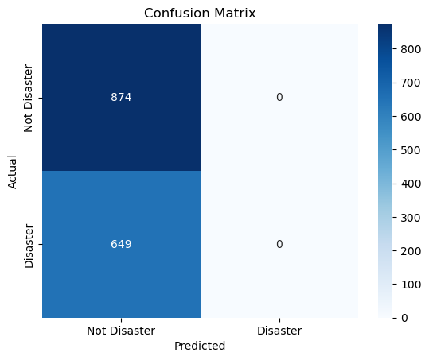

```python
from sklearn.metrics import confusion_matrix
import seaborn as sns
import matplotlib.pyplot as plt

# Predict on the test set
y_pred = model.predict(X_test)
y_pred_binary = (y_pred > 0.5).astype(int)  # Convert probabilities to binary predictions

# Create a confusion matrix
conf_matrix = confusion_matrix(y_test, y_pred_binary)

# Plot the confusion matrix using seaborn
sns.heatmap(conf_matrix, annot=True, fmt='d', cmap='Blues', xticklabels=['Not Disaster', 'Disaster'], yticklabels=['Not Disaster', 'Disaster'])
plt.xlabel('Predicted')
plt.ylabel('Actual')
plt.title('Confusion Matrix')
plt.show()
```

### Hyperparameter Tuning

```python
# hyperparameter updates
model2 = Sequential()
model2.add(Embedding(input_dim=5000, output_dim=128, input_length=X_train.shape[1]))
model2.add(LSTM(100))
model2.add(Dense(1, activation='sigmoid'))

# Compile the model
model2.compile(loss='binary_crossentropy', optimizer='adam', metrics=['accuracy'])

# Train the model
model2.fit(X_train, y_train, epochs=5, batch_size=64, validation_data=(X_test, y_test))
```

```
<keras.src.callbacks.History at 0x7f968f4a3730>
```

```python
# Accuracy of LSTM model with hyperparameter adjustments

results2 = model2.evaluate(X_test, y_test)

# Print the accuracy
print("Test Accuracy:", results2[1])
```

```
Test Accuracy: 0.5738673806190491
```

## Model Comparison

I am going to look at a more simple neural network model to train this data on to see if it performs better. I am going to create a CNN model to see if it has higher accuracy than the LSTM model. I will do a 1D CNN model because this is text data.

```python
from tensorflow.keras.layers import Embedding, Conv1D, GlobalMaxPooling1D, Dense
```

```python
# Reshape input data for 1D CNN
X_train_CNN = np.expand_dims(X_train, axis=-1)
X_test_CNN = np.expand_dims(X_test, axis=-1)
```

```python
# Define the CNN model
model_CNN = Sequential()
model_CNN.add(Conv1D(128, 5, activation='relu', input_shape=(X_train.shape[1], 1)))
model_CNN.add(GlobalMaxPooling1D())
model_CNN.add(Dense(1, activation='sigmoid'))
```

```python
# Compile the model
model_CNN.compile(loss='binary_crossentropy', optimizer='adam', metrics=['accuracy'])
```

```python
# Print a summary of the model architecture
model_CNN.summary()
```

```
Model: "sequential_2"
_________________________________________________________________
 Layer (type)                Output Shape              Param #
=================================================================
 conv1d (Conv1D)             (None, 4996, 128)         768

 global_max_pooling1d (Glob  (None, 128)               0
 alMaxPooling1D)

 dense_2 (Dense)             (None, 1)                 129

=================================================================
Total params: 897 (3.50 KB)
Trainable params: 897 (3.50 KB)
Non-trainable params: 0 (0.00 Byte)
_________________________________________________________________
```

```python
# Train the model
model_CNN.fit(X_train, y_train, epochs=5, batch_size=64, validation_data=(X_test, y_test))
```

```
<keras.src.callbacks.History at 0x7f968e6bf8b0>
```

### Accuracy of CNN Model

```python
# Evaluate the model on the test set
results3 = model_CNN.evaluate(X_test, y_test)

# Print the accuracy
print("Test Accuracy:", results3[1])
```

```
Test Accuracy: 0.5732107758522034
```

The accuracy of the CNN model is just slightly lower than both LSTM models. Overall the models perform all about the same.

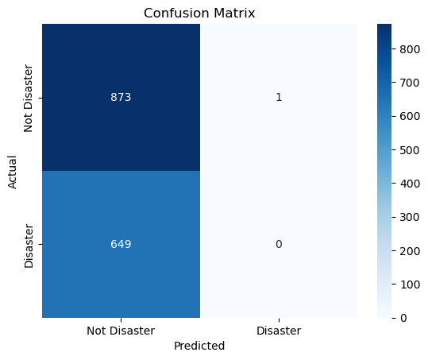

```python
# Prediction and Confusion Matrix of CNN Model
# Predict on the test set
y_pred_CNN = model_CNN.predict(X_test_CNN)
y_pred_binary_CNN = (y_pred_CNN > 0.5).astype(int)  # Convert probabilities to binary predictions

# Create a confusion matrix
conf_matrix = confusion_matrix(y_test, y_pred_binary_CNN)

# Plot the confusion matrix using seaborn
sns.heatmap(conf_matrix, annot=True, fmt='d', cmap='Blues', xticklabels=['Not Disaster', 'Disaster'], yticklabels=['Not Disaster', 'Disaster'])
plt.xlabel('Predicted')
plt.ylabel('Actual')
plt.title('Confusion Matrix')
plt.show()
```

# Conclusion

In the future I would fine tune the hyperparameters even more to see which would create the best model accuracy. There are also other neural network models that I would run to see if they performed better at classification for this data set.

Takeaways and learnings from this mini project shows that it is difficult to chose a correct neural network model for classification and prediction. Maybe a feedforward neural network would perform better on this data set because it is text data and feedforward neural networks perform well on text prediction data. Feedforward models are also flexible so it could scale well to this dataset.